# CS 422 Homework 9

Xingli Li

## Homework 9

### Part 2

set work space and install dependent package.

```r
library(cluster)
library(ggplot2)
library(factoextra)
library(fpc)
library(dbscan)

setwd(getwd())
```

### 2.1-(a)

Do you think it is necessary to standardize the dataset? Justify your answer.

Answer:

[output not shown]

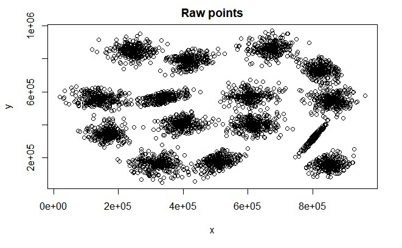

```r
df <- read.csv("s1.csv", encoding = 'UTF-8')
df.standardized <- scale(df)

plot(df, main="Raw points")
```

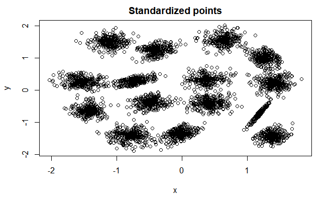

```r
plot(df.standardized, main="Standardized points")
```

### 2.1-(b)

Plot the dataset and describe in 1-2 sentences what you observe (visually) in the plot: how many clusters do you see? Are they well-separated?

Answer:

```
  There are 15 clusters in the plot. They are all clustered based on density and  they are well-separated, some are circular, rectangular, and some are long strips.
```

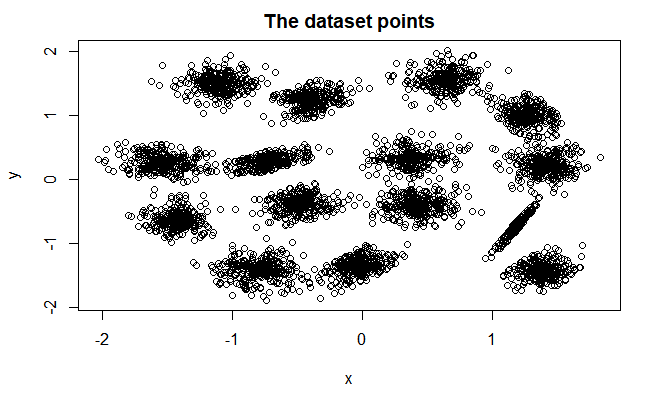

```r
plot(df.standardized, main="The dataset points")
```

### 2.1-(c)-(i)

Let’s see how many clusters K-Means finds.

Using the “wss” method, draw the scree plot for the optimal number of clusters

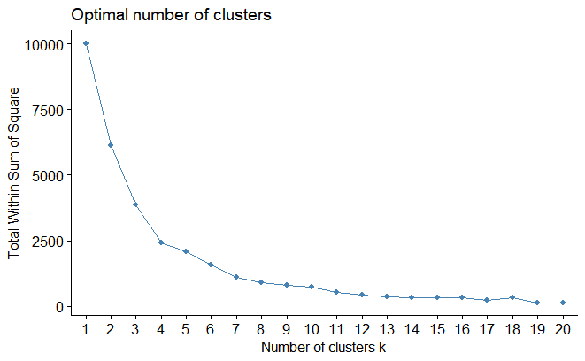

```r
# set.seed(123)

# indx <- sample(1:nrow(df), 0.20*nrow(df))

# df_sample <- df[indx,]

fviz_nbclust(df.standardized, kmeans, method="wss",k.max=20)
```

### 2.1-(c)-(ii)

Using the “silhouette” method, draw the scree plot for the optimal number of clusters.

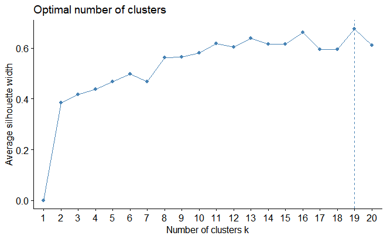

```r
fviz_nbclust(df.standardized, kmeans, method="silhouette", k.max=20)
```

### 2.1-(c)-(iii)

What do you think is the appropriate number of clusters if we were to use K-Means clustering on this dataset?

Answer:

```
  I think the appropriate number of clusters is 16.
```

### 2.1-(d)-(i)

Using the answer to (c)(iii), perform K-Means clustering on the dataset and plot the results.

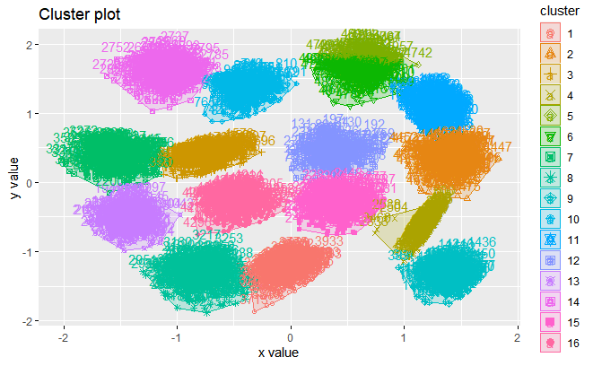

```r
km <- kmeans(df.standardized, centers=16,nstart=16)

fviz_cluster(km, df.standardized)
```

### 2.1-(d)-(ii)

Comment on how K-Means has clustered the dataset. (1-2 sentences.)

Answer:

```
  The K-Means algorithm does not cluster well in this dataset. There are clusters were merged, clearly different from what we observed.
```

### 2.1-(e)-(i)

We will now perform dbscan on this dataset.

What is the value of MinPts that you think is reasonable for this dataset? Why?

Answer:

[output not shown]

### 2.1-(e)-(ii)

In order to find the value of ɛ (eps), we need to calculate the average distance of every point to its k nearest neighbors. Set the value of k to be the result you obtained in (e)(i). Then, using this value determine what the correct value for ɛ should be. (Hint: Look at the online manual page for the function kNNdistplot()).

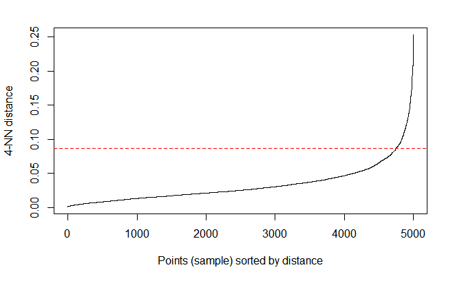

```r
# find the best value of ɛ that clusters by kNNdistplot()
# Find the 'elbow' in the graph.

k <- 4
eps <- 0.087

dbscan::kNNdistplot(df.standardized, k)
abline(h = eps, col = "red",lty=2)
```

```r
dbscan(df.standardized, eps, minPts = k)
```

```
DBSCAN clustering for 5000 objects.
Parameters: eps = 0.087, minPts = 4
The clustering contains 15 cluster(s) and 109 noise points.

  0   1   2   3   4   5   6   7   8   9  10  11  12  13  14  15
109 281   5 328 311 990 310 320 661 328 345 329   3 671   5   4

Available fields: cluster, eps, minPts
```

Answer:

```
  At minPts = 4, eps = 0.087, there are 15 clusters.
```

### 2.2-(a)

The dataset is available in Blackboard in the file countries.csv. Read in the dataset in a data frame taking care to allocate the first column to the name of the row instead of an attribute; this will allow the row name to be displayed in a PCA biplot. (Hint: See row.names parameter for the read.csv(…) method.)

### 2.2-(a)-(i)

Print a summary of all of the attributes in the dataset to become familiar with their values and ranges.

```r
options(digits = 3)

X <- read.csv("countries.csv", encoding = 'UTF-8',row.names = 1)

summary(X)
```

```
      GDP             HIV           Lifeexp          Mil          Oilcons           Pop            Tel          Unempl
 Min.   : 3685   Min.   :0.100   Min.   :65.9   Min.   :0.50   Min.   : 0.80   Min.   :  33   Min.   : 44   Min.   : 2.90
 1st Qu.: 9640   1st Qu.:0.100   1st Qu.:72.6   1st Qu.:1.35   1st Qu.: 5.25   1st Qu.:  60   1st Qu.:241   1st Qu.: 4.15
 Median :27418   Median :0.300   Median :78.0   Median :2.50   Median :11.30   Median : 109   Median :433   Median : 6.60
 Mean   :22296   Mean   :0.413   Mean   :76.1   Mean   :2.25   Mean   :10.91   Mean   : 263   Mean   :391   Mean   : 6.42
 3rd Qu.:31832   3rd Qu.:0.650   3rd Qu.:79.8   3rd Qu.:2.70   3rd Qu.:15.10   3rd Qu.: 212   3rd Qu.:550   3rd Qu.: 7.95
 Max.   :43369   Max.   :1.100   Max.   :82.0   Max.   :4.30   Max.   :25.10   Max.   :1322   Max.   :658   Max.   :12.50
```

```r
row.names(X)
```

```
 [1] "Brazil"      "Canada"      "China"       "France"      "Germany"     "India"       "Indonesia"   "Italy"       "Japan"
[10] "Mexico"      "Russia"      "South Korea" "Spain"       "UK"          "USA"
```

### 2.2-(a)-(ii)

Plot a boxplot of all of the attributes. There are two outliers associated with the Pop boxplot. What do you think they represent?

Answer:

```
  That two outliers are the population of China and the population of India. That two outliers are real, not noise.
```

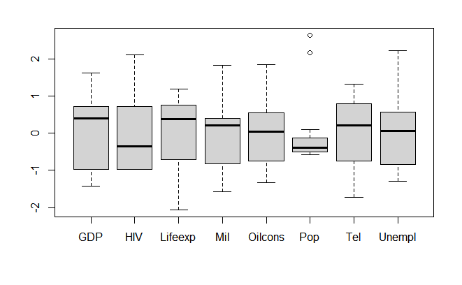

```r
X.standardized <- scale(X)

boxplot(X.standardized)
```

### 2.2-(b)-(i)

Print the summary of the PCA object. How many components explain at least 90% of the variance?

Answer:

```
  4 components.
```

```r
pca <- prcomp(X, scale.=T)
summary(pca)
```

```
Importance of components:
                         PC1   PC2   PC3    PC4   PC5    PC6    PC7    PC8
Standard deviation     2.060 1.138 1.017 0.8690 0.593 0.4173 0.3323 0.1833
Proportion of Variance 0.531 0.162 0.129 0.0944 0.044 0.0218 0.0138 0.0042
Cumulative Proportion  0.531 0.693 0.822 0.9162 0.960 0.9820 0.9958 1.0000
```

### 2.2-(b)-(ii)

Draw a screeplot of the PCA object.

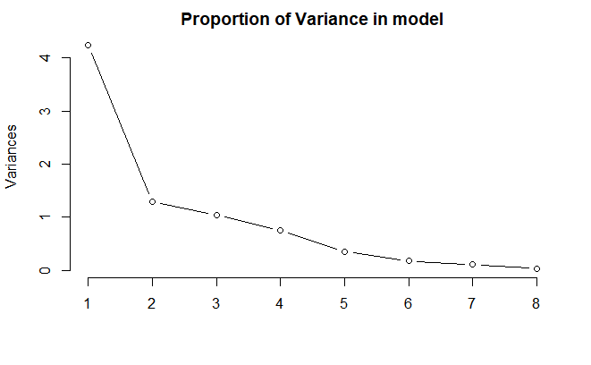

```r
screeplot(pca,type="l",main="Proportion of Variance in model")
```

### 2.2-(b)-(iii)

Based on the screeplot, how many principal components would you use for modeling?

Answer:

```
  I will use first 3 principal components for modeling. The first 3 principal components have effect for more than 80%.
```

### 2.2-(c)-(i)

Print the PCA components (the “rotation” field of the PCA object). Let’s focus on PC1 and PC2.

Which attributes is PC1 positively correlated with, and which attributes is it negatively correlated with? Based on this, what is your expectation of PC1?

Answer:

```
  PC1 positively is correlated with GDP, Lifeexp, Oilcons and Tel attributes.
  PC1 negatively is correlated with HIV, Mil, Pop, Unempl attributes.
```

```r
pca$rotation
```

```
           PC1     PC2      PC3     PC4     PC5     PC6    PC7     PC8
GDP      0.456  0.0636 -0.27109 -0.0544  0.1495 -0.0800  0.147  0.8132
HIV     -0.193 -0.3280 -0.69422  0.4840  0.1955 -0.2380  0.146 -0.1505
Lifeexp  0.441  0.0145  0.18765 -0.1449  0.4481 -0.2483  0.568 -0.4047
Mil     -0.196  0.5671 -0.48008 -0.4163 -0.3252 -0.0500  0.334 -0.1275
Oilcons  0.428  0.0364 -0.32045  0.0465  0.0784  0.7889 -0.118 -0.2617
Pop     -0.315  0.5419  0.00664  0.0798  0.7264  0.0526 -0.258  0.0601
Tel      0.442  0.1409 -0.20009 -0.1121 -0.0727 -0.4944 -0.647 -0.2519
Unempl  -0.210 -0.5017 -0.19001 -0.7399  0.3064  0.0571 -0.152  0.0208
```

```r
pca$rotation[,1:2]
```

```
           PC1     PC2
GDP      0.456  0.0636
HIV     -0.193 -0.3280
Lifeexp  0.441  0.0145
Mil     -0.196  0.5671
Oilcons  0.428  0.0364
Pop     -0.315  0.5419
Tel      0.442  0.1409
Unempl  -0.210 -0.5017
```

### 2.2-(c)-(ii)

Which attributes is PC2 positively correlated with, and which attributes is it negatively correlated with? Based on this, what is your expectation of PC2?

Answer:

```
  PC2 positively is correlated with GDP, Lifeexp, Mil, Oilcons, Pop and Tel attributes.
  PC2 negatively is correlated with HIV, Unempl attributes.
```

### 2.2-(d)-(i)

Draw a biplot with the first and second components. Examine the rotated variables (the “x” field of the PCA object) for the first and second component for Brazil, UK, and Japan. Print these two columns out.

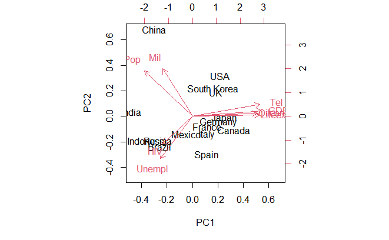

```r
biplot(pca)
```

```r
print(pca$x[c("Brazil","UK","Japan"), 1:2])
```

```
         PC1     PC2
Brazil -2.04 -1.0400
UK      1.46  0.8345
Japan   2.01 -0.0574
```

### 2.2-(d)-(ii)

Using the information in (d)(i)(ii), provide reasons whether the values for PC1 and PC2 for Brazil, UK, and Japan make sense.

Answer:

[output not shown]